# PELATIHAN KOMPUTASI 2023

# PYTHON

## Abduh Riski, S.Si., M.Si.

# Materi

1 Pendahuluan  
2 Tipe Data, Variabel, Input, Operator Aritmatika  
3 Operator Relasional, Struktur Pemilihan, Perulangan, Peloncatan, Operasi Logika, Bitwise  
4 List  
5 Function, Tuple, Dictionaries  
6 Modules, Packages dan PIP

# 1 Pendahuluan

# 1.1 Pengenalan Python

## Instalasi Python dan Editor

Berikut beberapa opsi instalasi python:

1. Tidak perlu install apapun -> Menggunakan [sandbox](https://pythonsandbox.com/) atau [Google Colab](https://colab.research.google.com/)
2. Install minimal python -> Download di [python.org](https://www.python.org/) (Sudah termasuk package manager pip dan IDLE)

   > Saat menginstall, silakan centang **add to path variable** dan **change minimum path length**
3. Install miniconda (minimum anaconda) - Command Line Interface (CLI) only [miniconda](https://docs.conda.io/en/latest/miniconda.html)
4. Install Anaconda - Graphical User Interface (GUI) (sudah bisa install spyder, VSCode, dll) [download](https://www.anaconda.com/products/distribution)

### Editor

1. IDLE dari python.org
2. Visual Studio Code -> microsoft. [download](https://code.visualstudio.com/)
3. Jupyter notebook di CLI baik menggunakan `pip` atau `conda`. [Install](https://jupyter.org/install)
4. Spyder IDE include dalam Anaconda atau [download](https://www.spyder-ide.org/)

```python
# Your First Program

print("Hello World")
```

# 1.2 Pengenalan Jupyter Notebook

```python
1+2
```

```python
2**3
```

```python
# komen
```

## Ini markdown

Bisa Juga digunakan untuk menulis persamaan dengan menggunakan syntax LATEX: $\int_a^b f(x) dx$

# 2 Tipe Data, Variabel, Input, Operator Aritmatika

# 2.1 Fungsi `print()`

```python
print("Hello, World!!!!!!")
print("Goodbye World!!!")
```

```python
print("Hello, Python!")
print("Petik satu atau dua")
print('Petik satu atau dua')
```

## Formatting dengan Special Character

- `\` = karakter spesial "escaping nature"
- `\n` = untuk enter
- `\t` = untuk tab
- `\'` dan `\"` = untuk menampilkan tanda petik
- `\\` = untuk backslash

```
print() = berarti line kosong
```

Tidak boleh ada 2 perintah dalam 1 baris

```
print("nama depan") print ("nama belakang")
```

```python
print("seketika langit menjadi gelap\nkemudian hujan turun dengan deras.")
print()
print("ibu memasak di dapur\ndan kakak menyapu di halaman.")
```

```python
print("\"")
```

```python
print("\\")
```

```python
# Dia mengatakan "halo"
print("Dia mengatakan \"halo\"")
```

Beberapa kalimat dapat dipisahkan dengan koma

```python
print("The itsy bitsy spider." , "climbed up." , "the waterspout.")
```

```python
print("My name is", "Python.")
print("Monty Python.")
```

`end=" "` digunakan untuk meletakkan argumen setelah argumen pertama

```python
print("My name is", "Python.", end=" ")
print("Monty Python.")
```

```python
print("My name is ", end=" ## ")
print("Monty Python.")
```

`sep=" "` digunakan untuk memisahkan antar argumen dengan string kosong atau karakter lain

```python
print("My", "name", "is", "Monty", "Python.", sep="-")
```

```python
print("My", "name", "is", sep="_", end="*")
print("Monty", "Python.", sep="*", end="*\n")
print("Digital", "Talent", "Dahsyat", sep="_", end="*")
print("Guntur", "Budi.", sep="*", end="*\n")
```

## Latihan

Buatlah Program untuk menghasilkan output: `Programming***Essentials***in...Python` menggunakan `sep` dan `end`.

```python
print("Programming","Essentials","in",sep="***",end="...")
print("Python")
```

## 2.2 Literals

Literal merupakan notasi untuk menyimbolkan nilai, dapat berupa string, boolean maupun angka (integer dan float)

```python
# hasil output akan terlihat sama, namun nilai tersebut tersimpan berbeda dalam memori komputer
print("2")
print(2)

print(type("2"))
print(type(2))
```

## Integers vs Floats

```python
print(5, "mempunyai tipe", type(5))

print(5.0, "mempunyai tipe", type(5.0))
```

## Penulisan Float dan Integer

Python versi 3 membolehkan pemisahan digit integer dengan underscore "_" agar mudah dibaca

```
print (10_000_000)
```

Float dipisahkan dengan .(titik) bukan ,(koma) cara penulisan float bisa 3 cara

> 3e08 berarti $3 \times 10^8$  
> 3e-08 berarti $3 \times 10^{-8}$

```python
print (0.000000003)
print (3e-8)
```

## String

```python
print("I'm Monty Python")
print("Jum'at")
print('"Saya berpendapat python itu mudah", kata Monty')
print("1.5")
print("1000")
```

```python
#string kosong pun juga bernilai string
print("")
print('')
```

## Booelan

Logika benar salah, 1 bernilai benar (True) dan 0 bernilai salah (False)

```python
print(True)
print(False)
print (3>0)
print (0>3)
```

## None

```python
print(None)
```

# 2.3 Operator

## Operator Aritmatika

| Operator | Arti | Contoh |
| --- | --- | --- |
| + | Penambahan | x + y |
| - | Pengurangan | x - y |
| * | Perkalian | x * y |
| / | Pembagian | x / y |
| % | Modulo - Sisa Pembagian | x % y (sisa pembagian of x/y) |
| // | Pembagian dan dibulatkan ke bawah | x // y |
| ** | Eksponen - Pangkat | x**y (x pangkat y) |

```python
#eksponen/pangkat
print(2 ** 3)
print(2 ** 3.)
print(2. ** 3)
print(2. ** 3.)
```

```python
#pembagian
print(6 / 3)
print(6 / 3.)
print(6. / 3)
print(6. / 3.)
```

```python
#pembagian dengan pembulatan ke bawah
print(6 // 3)
print(6 // 3.)
print(6. // 3)
print(6. // 3.)
```

```python
print(6 // 4)
print(6. // 4)

print(6 / 4)
print(6. / 4)

#Penting ! pembulatan selalu ke nilai bawahnya
```

```python
print(-6 // 4)
print(6. // -4)
```

```python
#modulo/sisa bagi
print(14 % 4)
```

```python
print(-4 + 4)
print(-4. + 8)
```

## Urutan Operator

| Prioritas | Operator | Keterangan |
| --- | --- | --- |
| 1 | () | tanda kurung |
| 2 | ** | eksponen |
| 3 | ~, +, - | komplemen, penjumlahan unary, pengurangan unary |
| 4 | *, /, %, // | perkalian, pembagian, modulo, hasil bagi |
| 5 | +, - | penjumlahan, pengurangan |

```python
#perkalian lebih didahulukan dari penambahan
2 + 3 * 5
```

```python
#pengerjaan dari kiri ke kanan
print(9 % 6 % 2)
```

```python
#pengerjaan dari kanan ke kiri
print(2 ** 2 ** 3)
```

```python
print((5 * ((25 % 13) + 100) / (2 * 13)) // 2)
```

# 2.4 Variabel

- Apa itu variabel?
- Bagaimana Aturan Penamaannya?

```python
# kamu bisa menaruh tipe data apapun dalam variabel
var = 1 # bukan operasi matematika, namun operasi assignment i.e., var <-- 1
print(var)
```

- baris pertama membuat variabel dengan nama `var`, dan diisi dengan nilai `1`.
- baris kedua mencetak nilai dalam variabel ke dalam console

```python
var = 1
saldo = 1000.0
namaKlien = 'John Doe'
print(var, saldo, namaKlien)
print(var)
```

```python
#case sensitive, huruf besar kecil perlu diperhatikan!
var = 1
print(Var)
```

```python
#tanda '+' bisa digunakan untuk kontatinasi untuk type string
var = "2023"
print("Digital talent: " + var)
```

```python
#menetapkan  nilai baru ke dalam variabel yang telah ada
#menugaskan variabel

var = 1
print(var)
var = var + 1
print(var)
```

```python
var = 100
var = 200 + 300
print(var)
```

```python
#Jalan Pintas operator

sheep = 5
sheep = sheep + 1
print(sheep)

sheep += 3
print(sheep)

sheep *= 2
print(sheep)
```

## Latihan

Tulis rumus ini dalam kode program:  
$c=\sqrt{a^2+b^2}$

```python
a = 3.0
b = 4.0
c = (a ** 2 + b ** 2) ** 0.5
print("c =", c)
```

# 2.5 Comments

```python
#this program computes the number of seconds in a given number of hours
# this program has been written two days ago

a = 2 # number of hours
seconds = 3600 # number of seconds in 1 hour

print("Hours: ", a) #printing the number of hours
# print("Seconds in Hours: ", a * seconds) # printing the number of seconds in a given number of hours

#here we should also print "Goodbye", but a programmer didn't have time to write any code
#this is the end of the program that computes the number of seconds in 3 hour
```

# 2.6 Input dan Output

katakunci `input()`  
hasil dari fungsi `input()` adalah **string**.  
Tidak bisa langsung dikenakan ke operasi aritmetika

```python
print("Tell me anything...")
anything = input()
print("Hmm...", anything, "... Really?")
```

```python
angka = input("Masukkan Angka...")
print("Pangkat duanya adalah", angka*2)
```

## Type Casting

```python
angka = float(input("Masukkan Angka..."))
print("Pangkat duanya adalah", angka**2)
```

```python
leg_a = float(input("Input first leg length: "))
leg_b = float(input("Input second leg length: "))
hypo = (leg_a**2 + leg_b**2) ** .5
print("Hypotenuse length is", hypo)
```

```python
fnam = input("May I have your first name, please? ")
lnam = input("May I have your last name, please? ")
print("Thank you.")
print("\nYour name is " + fnam + " " + lnam + ".")
```

```python
#Replication

print("+" + 10 * "-" + "+")
print(("|" + " " * 10 + "|\n") * 5, end="")
print("+" + 10 * "-" + "+")
```

```python
leg_a = float(input("Input first leg length: "))
leg_b = float(input("Input second leg length: "))
print("Hypotenuse length is " + str((leg_a**2 + leg_b**2) ** .5))
```

## Latihan

Tugasmu adalah mempersiapkan kode simpel untuk menentukan waktu akhir/selesai sebuah kegiatan. Diberikan variabel durasi waktu dalam menit dan waktu mulai dalam jam (0..23)dan menit (0..59). hasilnya harus dicetak dalam console

sebagai contoh, jika suatu kegiatan dimulai pukul `12:17` dan berlangsung selama `59 minutes` , maka kegiatan tersebut tersebut akan selesai pukul `13:16`

jangan takut kalau kodemu belum sempurna, tidak masalah waktunya terlihat tidak valid, yang terpenting kodenya dapat menghasilkan nilai yang valid berdasarkan data input.

Kode Dasar:

```
jam = int(input("waktu mulai (jam): "))
menit = int(input("waktu mulai (menit): "))
durasi= int(input("durasi kegiatan (minutes): "))

# Letakkan kodemu disini
```

Uji Kodemu, Petunjuk ! gunakan operator % sebagai kunci suksesmu ,,

```python
# coba di cek lagi

jam = int(input("waktu mulai (jam): "))
menit = int(input("waktu mulai (menit): "))
durasi = int(input("durasi kegiatan (menit): "))

tambah_menit = menit + durasi
tambah_jam = int(tambah_menit / 60)

jam += tambah_jam
menit = tambah_menit % 60

print(str(jam%24)+':'+str(menit))
```

# 3 Operator Relasional, Struktur Pemilihan, Perulangan, Peloncatan, Operasi Logika, Bitwise

# 3.1 Operator Relasional

Operator relasional adalah operator yang digunakan untuk membandingkan dua buah nilai. Hasil yang akan diperoleh dari operasi perbandingan ini adalah logika (bertipe bool), yaitu True (benar) atau False (salah).

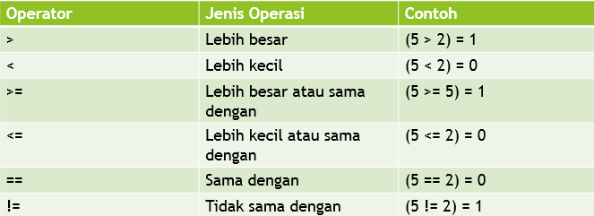

```python
a = int(input("masukkan a = "))
b = int(input("masukkan b = "))
c = int(input("masukkan c = "))
d = int(input("masukkan d = "))

print("a==b",a==b)
print("a==c",a==c)
print("a!=b",a!=b)

print("a>d",a>d)
print("b<d",b<d)
print("b<=d",b<=d)
print("b>=d",b>=d)
```

# 3.2 Struktur Pemilihan

Berbeda dengan bahasa pemrograman lainnya, Python hanya memiliki satu statement untuk melakukan proses pemilihan, yaitu dengan menggunakan if. Untuk mempermudah pembahasan tentang statement if, pembahasan akan dibagi menjadi tiga kelompok :

- Statement if untuk satu kasus
- Statement if untuk dua kasus
- Statement if untuk tiga kasus

## 1. Statement IF untuk satu kasus

Bentuk umum penggunaan perintah if untuk satu kasus dalam Python adalah :

```
if kondisi:
    statement1
    statement2
    ...
```

Pada bentuk diatas, statement1, statement2 dan seterusnya hanya akan dieksekusi jika kondisi yang didefinisikan dalam perintah If terpenuhi (bernilai True). Jika kondisi bernilai False, statement tersebut akan diabaikan oleh program.

Perhatikan contoh berikut :

```python
a = 6
b = 6

if a==b:
    print("terkesekusi")
    print("Tes")

print("Halo")
```

## 2. Statement IF untuk dua kasus

Untuk pemilihan yang mengandung dua kasus, bentuk umum yang digunakan adalah :

```
if kondisi :
    statement1
    statement2
    ...
else:
    statement_alternatif1
    statement_alternatif2
    ...
```

Pada bentuk ini, jika kondisi bernilai True makan statement selanjutnya yang akan dieksekusi oleh program adalah statement1, stetement 2 dan seterusnya. Tapi jika kondisi bernilai False, maka program akan mengeksekusi statement yang berada pada bagian else, yaitu statement_alternatif1, statement_alternatif2 dan seterusnya.

Perhatikan contoh dibawah :

```python
a = 5
b = 5

if a==b:
    print("a dan b bernilai sama")
else:
    print("a dan b bernilai berbeda")
    print("Halo")
```

```python
# read two numbers
number1 = int(input("Enter the first number: "))
number2 = int(input("Enter the second number: "))

# choose the larger number
if number1 > number2:
    largerNumber = number1
else:
    largerNumber = number2

# print the result
print("The larger number is:", largerNumber)
```

## Latihan

```python
bilangan = int(input("Masukkan bilangan bulat :  "))

if bilangan %2 ==0:
    print(str(bilangan) + " adalah bilangan genap")
else:
    print(str(bilangan) + " adalah bilangan ganjil")
```

## 3. Statement IF untuk tiga kasus atau lebih

Struktur pemilihan jenis ini merupakan bentuk yang paling kompleks jika dibandingkan dengan kedua jenis yang sudah di bahas diatas. Dalam struktur ini, ada beberapa kondisi yang harus diperiksa oleh program. Bentuk umum penggunaan perintah if untuk tiga kasus atau lebih adalah :

```
if kondisi1:
    statement1a
    statement1b
    ...
elif kondisi2:
    statement2a
    statement2b
    ...
else:
    statement_alternatif1
    statement_alternatif2
    ...
```

Perhatikan contoh dibawah ini :

```python
a = 80

if a > 80:
    print("Lulus")
elif a > 60:
    print("Mengulang Sebagian")
elif a > 40:
    print("Mengulang Keseluruhan")
else:
    print("Tidak Lulus")
```

```python
x = 10

if x > 5: # True
    if x == 6: # False
        print("nested: x == 6")
    elif x == 10: # True
        print("nested: x == 10")
    else:
        print("nested: else")
else:
    print("else")
```

## Latihan

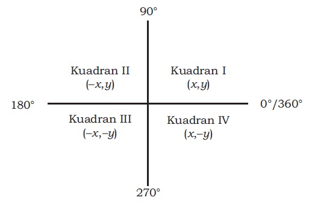

Tuliskan kondisi tersebut dalam bahasa Python.

```python
def main():
    #input nilai x dan y
    print("Memasukkan nilai koordinat")
    x = int(input("Masukkan nilai x :"))
    y = int(input("Masukkan nilai y :"))

    #memeriksa nilai x dan y
    if x>0 and y>0 :
        print("Koordinat ("+ str(x) + "," + str(y) +") berada pada kuardran  " + "I")
    elif x<0 and y>0 :
        print("Koordinat ("+ str(x) + "," + str(y) +") berada pada kuardran  " + "II")
    elif x<0 and y<0 :
        print("Koordinat ("+ str(x) + "," + str(y) +") berada pada kuardran  " + "III")
    elif x>0 and y<0 :
        print("Koordinat ("+ str(x) + "," + str(y) +") berada pada kuardran  " + "IV")
    else :
        pass
main()
```

## Latihan

1. Apakah luaran dari syntax berikut :

```python
x = 5
y = 10
z = 8

print(x > y)
print(y > z)
```

1. Apakah luaran dari syntax berikut :

```python
x, y, z = 5, 10, 8

print(x > z)
print((y - 5) == x)
```

1. Apakah luaran dari syntax berikut :

```python
x, y, z = 5, 10, 8
x, y, z = z, y, x

print(x > z)
print((y - 5) == x)
```

1. Apakah luaran dari syntax berikut :

```python
x = 10

if x == 10:
    print(x == 10)

if x > 5:
    print(x > 5)

if x < 10:
    print(x < 10)
else:
    print("else")
```

1. Apakah luaran dari syntax berikut :

```python
x = "1"

if x == 1:
    print("one")
elif x == "1":
    if int(x) > 1:
        print("two")
    elif int(x) < 1:
        print("three")
    else:
        print("four")
if int(x) == 1:
    print("five")
else:
    print("six")
```

1. Apakah luaran dari syntax berikut :

```python
x = 1
y = 1.0
z = "1"

if x == y:
    print("one")
if y == int(z):
    print("two")
elif x == y:
    print("three")
else:
    print("four")
```

# 3.3 Struktur Perulangan

Python menyediakan dua statement untuk melakukan proses perulangan yaitu for dan while. Diantara kedua statement ini, secara umum for lebih banyak digunakan daripada while.

## 1. Statement WHILE

Sama seperti kebanyakan bahasa pemrograman lainnya, Python juga mendukung statement while untuk melakukan perulangan satu atau sekelompok statement. Bentuk umum dari perulangan while adalah sebagai berikut :

```
while kondisi:
    statement1
    statement2
    statement1
    :
    :
    statementn
```

Pada bentuk perulangan diatas, statement1, statement2 dan seterusnya merupakan sekelompok statement yang akan diulang. Statement tersebut akan terus dieksekusi/ diulang selama kondisi bernilai True. Maka diperlukan sebuah statement yang akan bernilai False, agar proses dapat berhenti. Perhatikan syntax berikut :

```python
i = 1
while i<10:
    print(i**2)
    i = i+2
```

```python
# we will store the current largest number here
largestNumber = -999999999

# input the first value
number = int(input("Enter a number or type -1 to stop: "))

# if the number is not equal to -1, we will continue
while number != -1:
    # is number larger than largestNumber?
    if number > largestNumber:
        # yes, update largestNumber
        largestNumber = number
    # input the next number
    number = int(input("Enter a number or type -1 to stop: "))

# print the largest number
print("The largest number is:", largestNumber)
```

Perhatikan contoh program untuk menghitung berapa ganjil dan genap dari rangkaian bilangan :

```python
# program that reads a sequence of numbers
# and counts how many numbers are even and how many are odd
# program terminates when zero is entered

oddNumbers = 0
evenNumbers = 0

# read the first number
number = int(input("Enter a number or type 0 to stop: "))

# 0 terminates execution
while number != 0:
    # check if the number is odd
    if number % 2 == 1:
        # increase the oddNumbers counter
        oddNumbers += 1
    else:
        # increase the evenNumbers counter
        evenNumbers += 1
    # read the next number
    number = int(input("Enter a number or type 0 to stop: "))

# print results
print("Odd numbers count:", oddNumbers)
print("Even numbers count:", evenNumbers)
```

## 2. Statement FOR

Selain menggunakan statement while, kita juga dapat melakukan perulangan dengan statement for. Perintah for biasanya digunakan untuk mengambil atau menelusuri data (item) yang terdapat pada tipe-tipe koleksi seperti string, list, tuple, dictionary dan set. Dalam pemrograman, proses penelusuran data dalam sebuah koleksi disebut iterasi. Selain itu, for juga dapat melakukan perulangan normal (sama seperti while), yaitu dengan menggunakan fungsi range(). Dengan menggunakan range(), kita akan dapat dengan mudah melakukan perulangan dari indeks awal ke indeks tertentu.

Bentuk perintah for dapat dituliskan sebagai berikut :

1. Statement for untuk perintah koleksi

   ```
   for indeks tipe koleksi:
    statement1
    statement2
    ...
   ```

2. Statement for untuk rentang nilai tertentu

   ```
   for indeks in range (nilai_awal, nilai_akhir, step):
    statement1
    statement2
    ...
   ```

   Perhatikan contoh-contoh dibawah ini :

```python
for i in range(5):
    print(i)
```

```python
for i in range(2, 8):
    print(i)
```

```python
for i in range(2, 18, 3):
    print(i)
```

## For - else

```python
for i in range(5):
    print(i)
else:
    print("masuk else")
```

# 3.4 Statement Peloncatan

Statement loncat merupakan perintah yang digunakan untuk memindahkan eksekusi program dari satu bagian tertentu ke bagian lain. Python menyediakan tiga statement yaitu : break, continue dan return.

## 1. Statement BREAK

Statement break digunakan untuk menghentikan secara paksa proses perulangan, meskipun kondisi perulangan sebenarnya masih bernilai True. Perhatikan contoh-contoh berikut ini :

```python
for i in range (11):
    print(i,end=' ')
    if i == 7:
        print("Masih dalam for ")
        break
```

```python
# break - example

print("The break instruction:")
for i in range(1, 6):
    if i == 3:
        break
    print("Inside the loop.", i)
print("Outside the loop.")
```

```python
largestNumber = -99999999
counter = 0

while True:
    number = int(input("Enter a number or type -1 to end program: "))
    if number == -1:
        break
    counter += 1
    if number > largestNumber:
        largestNumber = number

if counter != 0:
    print("The largest number is", largestNumber)
else:
    print("You haven't entered any number.")
```

## 2. Statement CONTINUE

Statement continue berguna untuk memaksa pengulangan agar memroses indeks selanjutnya meskipun statement didalam blok pengulangan sebenarna belum semua di eksekusi. Dengan kata lain, statement yang ada dibawah statement continue akan diabaikan (tidak dieksekusi)

```python
for i in range (1,11):
    if i % 2 ==0:
        continue
    print(i, end='\t')
```

```python
# continue - example

print("\nThe continue instruction:")
for i in range(1, 6):
    if i == 3:
        continue
    print("Inside the loop.", i)
print("Outside the loop.")
```

```python
largestNumber = -99999999
counter = 0

number = int(input("Enter a number or type -1 to end program: "))

while number != -1:
    if number == -1:
        continue
    counter += 1

    if number > largestNumber:
        largestNumber = number
    number = int(input("Enter a number or type -1 to end program: "))

if counter:
    print("The largest number is", largestNumber)
else:
    print("You haven't entered any number.")
```

## Latihan

1. Buatlah perulangan dengan menggunakan for yang mulai dari 0 sampai dengan 10, dan cetak nomer ganjil pada layar.
2. Buatlah perulangan dengan menggunakan while dari 0 sampai dengan 10, dan cetak nomer ganjil pada layar
3. Buatlah sebuah program dengan perulangan for dan statement break. Program harus diiterasi sebanyak jumlah karakter didalam sebuah alamat email, dan loop akan berhenti jika menemukan simbol '@' dan cetak karakter yang ditemukan sebelum simbol '@' didalam sebuah line
4. Buatlah sebuah perulangan loop dan statement continue. Program harus diiterasi sebanyak nomer yang ditemukan dalam string (digit = "0165031806510"), ganti 0 dengan x, lalu cetak string yang telah dimodifikasi.
1. Apakah output dari kode berikut?

```python
n = 3

while n > 0:
    print(n + 1)
    n -= 1
else:
    print(n)
```

1. Apakah output dari kode berikut?

```python
n = range(4)

for num in n:
    print(num - 1)
else:
    print(num)
```

1. Apakah output dari kode berikut?

```python
for i in range(0, 6, 3):
    print(i)
```

### JAWABAN

```python
for i in range(1, 11):
    if i % 2 !=0:
        print(i,end=' ')
```

```python
x=1
while x<11:
    if x % 2 !=0:
        print(x,end=' ')
    x +=1
```

```python
for ch in "riski.fmipa@unej.ac.id":
    if ch == "@":
        break
    print(ch,end=' ')
```

```python
for digit in "0165031806510":
    if digit == "0":
        print ("x")
        continue
    print(digit)
```

# 3.5 Operasi Logika

Operasi Logika `and`

| Argument A | Argument B | A and B |
| --- | --- | --- |
| False | False | False |
| False | True | False |
| True | False | False |
| True | True | True |

Operasi Logika `or`

| Argument A | Argument B | A or B |
| --- | --- | --- |
| False | False | False |
| False | True | True |
| True | False | True |
| True | True | True |

Operasi Logika `not`

| Argument | not Argument |
| --- | --- |
| False | True |
| True | False |

> If we have some free time, **and** the weather is good, we will go for a walk

> If you are in the mall **or** I am in the mall, one of us will buy a gift for Mom.

Perhatikan contoh dibawah ini :

```python
x = 1
y = 0

z = ((x == y) and (x == y)) or not(x == y)
print(not(z))
```

# 3.6 Operasi Bitwise

Operator bitwise sebenarnya sama saja dengan operator logika. Perbedaannya, dalam operasi bitwise kedua operand-nya bertipe bilangan bulat (integer) dan operasinya dilakukan bit-demi-bit. Maka dari itu , bilangan integer yang dijadikan sebagai operand, terlebih dahulu akan dikonversi kedalam biner.

[figure not shown]

Konsep logika dari operator &, |, dan ~ sama seperti operator and, or, dan not yang terdapat pada operator logika. Perbedaannya hanya operator bitwise beroperasi pada masing-masing bit.

Operator ^(XOR) hanya akan menghasilkan nilai True jika salah satu operand (bukan keduanya bernilai True, selain daripada itu adalah False sebagaimana terlihat pada gambar berikut:

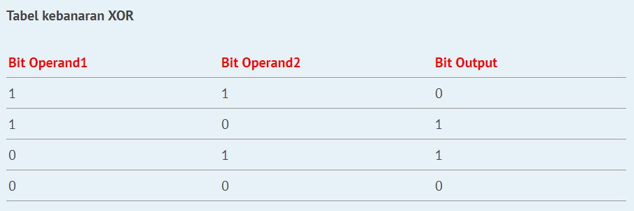

Sebagai contoh :

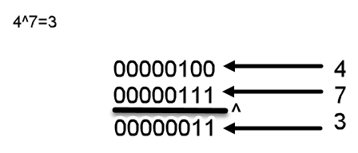

Operator << akan menggeser n bit kearah kiri dari bilangan binernya. Setiap pergeseran 1 bit akan menghasilkan nilai operand dikali 2. Sebagai contoh :

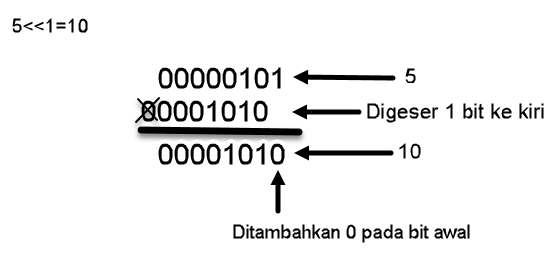

Operator >> akan menggeser n bit kearah kanan dari bilangan binernya. Setiap pergeseran 1 bit akan menghasilkan nilai operand dibagi 2. Jika operand bernilai ganjil, maka sisa pembagi akan diabaikan. Sebagai contoh :

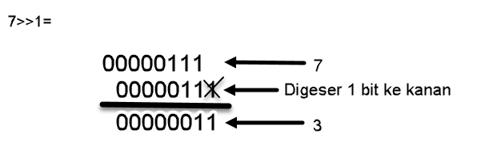

# 4 List

# List dan Array

Tipe list dalam python sebenernya mirip dengan array normal pada bahasa pemrograman lain. List juga dapat menampung beberapa tipe data sekaligus.

Bentuk umum untuk membuat list dalam python adalah :

```
nama_list = [nilai1, nilai2, nilai3,...]
```

Perhatikan contoh dibawah ini :

```python
var1 = 10
var2 = 5
var3 = 7
var4 = 2
var5 = 1

# VERSUS #

var = [10, 5, 7, 2, 1]
print(var)
```

```python
#bisa menampung berbagai tipe data
var = ["Digital", 90 , 1000.50 , "Talent"]
print(var)
```

# Indexing

Dalam list, elemen tidak diindeks berdasarkan key tertentu yang namanya bisa didefinisikan sendiri melainkan berdasarkan indeks bilangan yang diawali dengan nilai nol(0). Perhatikan contoh berikut :

```python
numbers = [10, 5, 7, 2, 1]
print(numbers)
print(numbers[2])
print(numbers[0])
```

```python
numbers = [10, 5, 7, 2, 1]
print("Original list content:", numbers) # printing original list content

numbers[0] = 111
print("\nPrevious list content:", numbers) # printing previous list content

numbers[1] = numbers[4] # copying value of the fifth element to the second
print("Previous list content:", numbers) # printing previous list content

print("\nList length:", len(numbers)) # printing the list's length
```

Indeks dapat juga bernilai negatif yaitu menghitung indeks mulai dari kanan. Perhatikan contoh berikut :

```python
lst = [100,200,300,400,500]
print(lst[-1])
print(lst[-2])
print(lst[-5])
```

# Slicing List

```python
lst = [4, 1, 6, 9, 10, 8]
print(lst[0:2])
print(lst[1:3])
print(lst[-3:])
print(lst[:-3])
print(lst[:])
```

```python
a = [100, 80, 50, 30, 120, 10]

#Tampilkan 80 50
print(a[1:3])

#Tampilkan 30 120 10
print(a[-3:])
print(a[3:])
print(a[3:6])

#Tampilkan 100 80 50 30
print(a[0:-2])
print(a[0:4])
```

```python
# mencari rata-rata nilai dari list berikut
# dengan menggunakan perulangan

a = [100, 80, 50, 30, 120, 10]
jumlah = 0
for i in a:
    jumlah += i

rata_rata = jumlah / len(a)
print(rata_rata)
```

# Swap

Nilai elemen didalam list selain dapat diakses juga dapat dimanipulasi dengan swapping. Perhatikan contoh berikut :

```python
# swap
numbers[0] , numbers[1] = numbers[1] , numbers[0]
print(numbers)
```

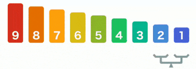

```python
myList = [8, 10, 6, 2, 4] # list to sort
swapped = True # it's a little fake - we need it to enter the while loop

while swapped:
    swapped = False # no swaps so far
    for i in range(len(myList) - 1):
        if myList[i] > myList[i + 1]:
            swapped = True # swap occured!
            myList[i], myList[i + 1] = myList[i + 1], myList[i]

print(myList)
```

```python
myList = []
swapped = True
num = int(input("How many elements do you want to sort: "))

for i in range(num):
    val = float(input("Enter a list element: "))
    myList.append(val)

while swapped:
    swapped = False
    for i in range(len(myList) - 1):
        if myList[i] > myList[i + 1]:
            swapped = True
            myList[i], myList[i + 1] = myList[i + 1], myList[i]

print("\nSorted:")
print(myList)
```

# Menambah Elemen ke dalam list

Terdapat tiga cara untuk menambahkan elemen baru kedalam sebuah list yaitu :

- Menggunakan metode append() : Metode ini digunakan untuk menambah elemen tunggal dibagian akhir list. Perhatikan contoh dibawah :

```python
buah = ["durian", "mangga", "apel"]
buah.append("jeruk")
print(buah)
```

```python
myList = [] # creating an empty list

for i in range(5):
    myList.append(i + 1)

print(myList)
```

- Menggunakan metode insert() : Metode ini digunakan untuk menambah elemen tunggal di indeks / posisi tertentu. Perhatikan contoh dibawah :

```python
buah = ["durian", "mangga", "apel"]
buah.insert(1,"kiwi")
print (buah)
```

- Menggunakan metode extend(). Metode ini digunakan untuk menyambung atau menggabungkan suatu list dengan list yang lain. Perhatikan contoh berikut :

```python
buah = ["durian", "mangga", "apel"]
buah.extend(["jeruk","melon"])
print(buah)
```

Perhatikan juga contoh dibawah ini :

```python
numbers = [111, 7, 2, 1]
print(len(numbers))
print(numbers)

###

numbers.append(4)

print(len(numbers))
print(numbers)

###

numbers.insert(0, 222)
print(len(numbers))
print(numbers)

#
```

# Menghapus Elemen kedalam list

Menghapus elemen dapat dilakukan dengan :

```
nama_list.remove(nilai)
```

atau dengan memberikan indeksnya menggunakan instruksi delete :

```
del nama_list[indeks]
```

```python
numbers = [5,4,3,2,1]

del numbers[1] # removing the second element from the list
print("New list's length:", len(numbers)) # printing new list length
print("\nNew list content:", numbers) # printing current list content
```

# Tambahan Method List

```python
lst = [5, 1, 3, 2, 10]
print(lst)
lst.sort()
print(lst)
lst.reverse()
print(lst)
```

```python
vehiclesOne = ['car', 'bicycle', 'motor']
print(vehiclesOne) # outputs: ['car', 'bicycle', 'motor']

vehiclesTwo = vehiclesOne
del vehiclesOne[0] # deletes 'car'
print(vehiclesTwo) # outputs: ['bicycle', 'motor']
print(vehiclesOne)
```

```python
vehiclesOne = ['car', 'bicycle', 'motor']
print(vehiclesOne) # outputs: ['car', 'bicycle', 'motor']

vehiclesTwo = vehiclesOne[:]
del vehiclesOne[0] # deletes 'car'
print(vehiclesTwo) # outputs: ['bicycle', 'motor']
print(vehiclesOne)
```

```python
nama = ["Ana","Budi","Citra"]
kata_kunci = "Budi"

print(kata_kunci not in nama)

if kata_kunci in nama:
    print("Nama "+kata_kunci+" ada di list")
```

```python
for i in range(10):
    print(i, end=" ")

print()
for i in range(1,7):
    print(i, end=" ")

print()
for i in range(1,10,2):
    print(i, end=" ")

print()
for i in range(10,-10,-2):
    print(i, end=" ")
```

```python
for i in range(1, 11):
    if i%2 != 0:
        print(i, end=" ")
```

```python
x = 1
while x < 11:
    if x%2!=0:
        print(x, end=" ")
    x += 1
```

```python
for ch in "riski.fmipa@unej.ac.id":
    if ch == "@":
        break
    print(ch,end="")
```

```python
for digit in "0165031806510":
    if digit == "0":
        print("x",end="")
        continue
    print(digit,end="")
```

# List Method (Advance)

Perhatikan contoh berikut :

```python
myList = [10, 1, 8, 3, 5]
total = 0

for i in range(len(myList)):
    total += myList[i]

print(total)
```

```python
#squares = [x ** 2 for x in range(10)]
#print (squares)

squares = []
for x in range(10):
    squares.append(x ** 2)
print(squares)
```

```python
twos = [2 ** i for i in range(8)]
print(twos)
```

```python
odds = [x for x in squares if x % 2 != 0 ]
print (odds)

# sama dengan
odds = []
for x in squares:
    if x % 2 != 0:
        odds.append(x)
print (odds)
```

# 1. List Dua Dimensi (Array)

List dapat berisi berbagai tipe data seperti strings, boolean maupun list lainnya. Kita sering sekali menemukan bentuk array seperti ini dikehidupan kita, salah satu contohnya adalah papan catur. Papan catur terdiri dari baris dan kolom, terdapat 8 baris dan juga 8 kolom. Setiap kolom ditandai oleh huruf A sampai dengan H, dan setiap baris ditandai oleh 1 sampai dengan 8.

Perhatikan kode berikut :

```python
# Contoh List di dalam List
k = [[3,5,1],[6,1,8],[9,10,4]]
print(k[1])
print(k[1][0])
print(k[-1][-2:])
```

```python
EMPTY = "-"
board = []

for i in range(8):
    row = [EMPTY for i in range(8)] #membuat satu list
    board.append(row) #membuat 8 list
    print(row)
#print(board)
```

List diatas menggambarkan list papan catur yang masih kosong sebagaimana gambar ilustrasi dibawah :

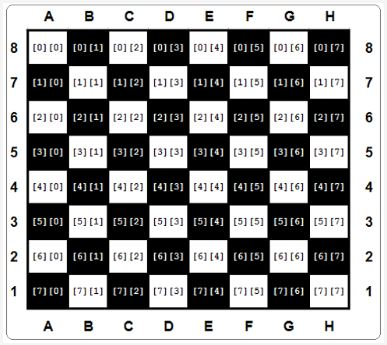

Mari kita isi list sersebut dengan sesuatu yang kita inginkan. Perhatikan kode berikut :

```python
EMPTY = "-"
ROOK = "ROOK"
KNIGHT = "KNIGHT"
PAWN = "PAWN"
board = []

for i in range(8):
    row = [EMPTY for i in range(8)]
    board.append(row)

#isi dengan ROOK
board[0][0] = ROOK
board[0][7] = ROOK
board[7][0] = ROOK
board[7][7] = ROOK

#isi dengan KNIGHT
board[4][2] = KNIGHT

#isi dengan PAWN
board[3][4] = PAWN


print(board)
```

# 2. List Multidimensi (Array)

Untuk mencari sebuah elemen pada list dua dimensi adalah dengan menggunakan dua koordinat yaitu nomer baris dan juga nomer kolom. Bayangkan ketika anda akan mengembangkan sebuah program untuk perekam cuaca otomatis. Alat ini akan mampu merekam suhu udara tiap jam sampai dengan satu bulan. Maka total data yang akan direkam adalah 24 jam x 31 hari = 744 data.

```python
temps = [[0.0 for h in range(24)] for d in range(31)]
print (temps)
```

Kemudian, berikan pengaturan sebagai berikut :

```python
temps = [[0.0 for h in range(24)] for d in range(31)]

# 1. the monthly average noon temperature
sum = 0.0

for day in temps:
    sum += day[11]

average = sum / 31

print("Average temperature at noon:", average)

# 2. the highest temperature during the whole month
highest = -100.0

for day in temps:
    for temp in day:
        if temp > highest:
            highest = temp

print("The highest temperature was:", highest)

# 3.count the days when the temperature at noon was at least 20 ℃
hotDays = 0

for day in temps:
    if day[11] > 20.0:
        hotDays += 1

print(hotDays, "days were hot.")
```

# 3. Array tiga dimensi

Python tidak memiliki batasan dalam list-in-list. Ini merupakan contoh untuk array tiga dimensi.

Bayangkan sebuah hotel yang besar terdiri dari tiga bangunan, 15 lantai untuk tiap bangunannya. Pada setiap lantai terdapat 20 kamar.

Langkah pertama adalah tentukan tipe data dari array yang akan dibuat. Dalam kasus ini nilai Boolean yang paling sesuai, nilai True jika kamar telah di pesan dan nilai False jika kamar kosong. Langkah kedua adalah dengan menganalisa kondisi yang diberikan.

Kode dibawah akan menghasilkan array :

```python
rooms = [[[False for r in range(20)] for f in range(15)] for t in range(3)]
print (rooms)
```

Coba berikan input untuk kondisi bibawah ini :

1. Pesan satu kamar pada gedung 2, lantai 10, kamar 14
2. Kosongkan satu kamar pada gedung 1, lantai 5, kamar 2
3. Periksa apakah ada kamar kosong di lantai 15

```python
rooms = [[[False for r in range(20)] for f in range(15)] for t in range(3)]

rooms[1][9][13] = True
rooms[0][4][1] = False

print(rooms)

vacancy = 0

for roomNumber in range(20):
    if not rooms[2][14][roomNumber]:
        vacancy += 1

print(roomNumber)
```

# 5 Function, Tuple, Dictionaries

# 5.1 Function

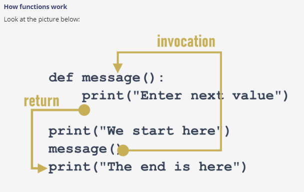

```python
# Motivasi function adalah perulangan kode

print("Please, Enter a value: ")
a = int(input())
print(a)

print("Please, Enter a value: ")
b = int(input())
print(b)

print("Please, Enter a value: ")
c = int(input())
print(c)

# can we do this: change made once in one place would be propagated to all the places where it's used.
```

Sintaks Function:

```
def functionName():
    functionBody
```

```python
def message():
    print("Please, Enter a value: ")
    a = int(input())
    print(a)

print("Dimulai dari sini")
message() #invocation
message()
message()
print("Berhenti disini")
```